# Operation Sticky Gate

Mojisoluwa (Jiso) Awe

# What is Operation Sticky Gate?

# Before the Crackdown

For a long time MLB teams had what some would call a gentleman’s agreement over utilizing foreign substances. Initially this started as a way for pitchers to better their grip on the ball when they pitched. Yet, now it’s gotten to the point that the foreign substances are so sticky that instead of just helping the pitchers grip the ball, it’s making the ball stick to their hand for longer, thus increasing the spin rate of the ball and making it harder to hit. As the spin of the ball increases the general location in which the ball is getting thrown is higher, adding to the difficulties hitters are facing. The spin on pitches like the 4-seam fastballs is a back spin, which opposes the downward force of gravity on the ball (think of the term ‘rising fastball’).

The MLB made a decision coming out against foreign substances by stating that starting on June 1st umpires will begin checking for pitchers using foreign substances and players caught using them will be removed from the game, placed on a 10 game suspension, and fined. Many people have argued that these statements won’t deter pitchers from utilizing foreign substances. Yet many analysts have been saying spin rates going down and batting averages going up. In this notebook we will be examining the affect of the MLB’s new implementation and examining changes with individual players.

The data referenced has been provided by Baseball Savant and Baseball Reference.

## Velocity vs Spin Rate

It’s important to note that generally as increases velocity so does spin rate. In this section we will be comparing pitchers spin rates vs velocities before and after June 1st.

```r
library(ggplot2) ## loading packages
library(ggExtra)
library(dplyr)
library(tidyverse)
```

```r
b4 <-
  read.csv('b4June1.csv')
b4
```

| pitches | player_id | player_name | total_pitches | pitch_percent | ba | iso | babip | slg | woba | xwoba | xba | hits | abs | launch_speed | launch_angle | spin_rate | velocity | effective_speed | whiffs | swings | takes | eff_min_vel | release_extension | pos3_int_start_distance | pos4_int_start_distance | pos5_int_start_distance | pos6_int_start_distance | pos7_int_start_distance | pos8_int_start_distance | … |
| --- | --- | --- | --- | --- | --- | --- | --- | --- | --- | --- | --- | --- | --- | --- | --- | --- | --- | --- | --- | --- | --- | --- | --- | --- | --- | --- | --- | --- | --- | --- |
| 915 | 621244 | Berríos, José | 915 | 100 | 0.223 | 0.158 | 0.294 | 0.381 | 0.292 | 0.340 | 0.261 | 48 | 215 | 86.4 | 10.5 | 2290 | 90.2 | 89.26 | 110 | 429 | 486 | -0.9 | 6.41 | 108 | 156 | 118 | 149 | 300 | 328 | … |
| 819 | 450203 | Morton, Charlie | 819 | 100 | 0.231 | 0.097 | 0.315 | 0.328 | 0.292 | 0.305 | 0.236 | 45 | 195 | 87.1 | 6.4 | 2559 | 89.1 | 88.86 | 109 | 379 | 440 | -0.2 | 6.28 | 109 | 151 | 121 | 150 | 300 | 321 | … |
| 807 | 628711 | Urías, Julio | 807 | 100 | 0.241 | 0.161 | 0.301 | 0.402 | 0.293 | 0.314 | 0.250 | 48 | 199 | 86.7 | 17.0 | 2657 | 89.4 | 88.32 | 110 | 415 | 392 | -1.1 | 5.53 | 112 | 156 | 116 | 150 | 299 | 317 | … |
| 779 | 554430 | Wheeler, Zack | 779 | 100 | 0.218 | 0.086 | 0.298 | 0.305 | 0.258 | 0.261 | 0.214 | 43 | 197 | 84.6 | 9.5 | 2373 | 95.3 | 96.66 | 102 | 396 | 383 | 1.4 | 7.17 | 112 | 152 | 116 | 150 | 297 | 323 | … |
| 776 | 605540 | Woodruff, Brandon | 776 | 100 | 0.126 | 0.038 | 0.186 | 0.164 | 0.177 | 0.249 | 0.189 | 23 | 183 | 86.2 | 5.1 | 2416 | 94.4 | 93.72 | 98 | 393 | 383 | -0.7 | 6.52 | 110 | 156 | 118 | 150 | 300 | 323 | … |
| 770 | 607192 | Glasnow, Tyler | 770 | 100 | 0.151 | 0.113 | 0.239 | 0.264 | 0.225 | 0.238 | 0.168 | 32 | 212 | 91.3 | 16.4 | 2556 | 94.1 | 95.40 | 137 | 394 | 376 | 1.3 | 7.37 | 107 | 159 | 119 | 150 | 302 | 321 | … |
| 751 | 605288 | Houser, Adrian | 751 | 100 | 0.230 | 0.137 | 0.267 | 0.366 | 0.300 | 0.317 | 0.242 | 37 | 161 | 89.3 | -0.2 | 2050 | 91.2 | 91.20 | 64 | 339 | 412 | 0.0 | 6.46 | 107 | 151 | 115 | 148 | 300 | 318 | … |
| 751 | 518876 | Kelly, Merrill | 751 | 100 | 0.274 | 0.177 | 0.326 | 0.452 | 0.338 | 0.344 | 0.270 | 51 | 186 | 90.6 | 11.5 | 2439 | 88.5 | 88.19 | 64 | 333 | 418 | -0.3 | 6.32 | 112 | 153 | 117 | 150 | 304 | 331 | … |
| 750 | 448179 | Hill, Rich | 750 | 100 | 0.199 | 0.125 | 0.254 | 0.324 | 0.270 | 0.320 | 0.242 | 35 | 176 | 90.1 | 14.1 | 2569 | 81.5 | 80.97 | 97 | 347 | 403 | -0.5 | 6.36 | 103 | 155 | 116 | 148 | 305 | 323 | … |
| 748 | 425844 | Greinke, Zack | 748 | 100 | 0.285 | 0.179 | 0.306 | 0.464 | 0.341 | 0.330 | 0.279 | 51 | 179 | 85.9 | 18.9 | 2293 | 83.5 | 82.77 | 58 | 326 | 422 | -0.7 | 5.96 | 114 | 155 | 116 | 151 | 289 | 324 | … |

[output cut: 610 more lines]

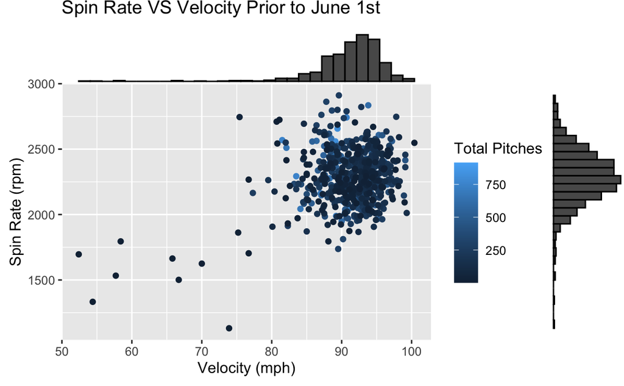

```r
b4gr <-
  b4 %>%
  ggplot(aes(x = velocity, y = spin_rate, color = total_pitches)) +
  geom_point(stat = 'identity') +
  xlab('Velocity (mph)') +
  ylab('Spin Rate (rpm)') +
  ggtitle('Spin Rate VS Velocity Prior to June 1st') +
  labs(color = 'Total Pitches')

p1 <-
  ggMarginal(b4gr, type = 'histogram')
p1
```

```r
aft <-
  read.csv('aftJune1st.csv')
aft
```

| pitches | player_id | player_name | total_pitches | pitch_percent | ba | iso | babip | slg | woba | xwoba | xba | hits | abs | launch_speed | launch_angle | spin_rate | velocity | effective_speed | whiffs | swings | takes | eff_min_vel | release_extension | pos3_int_start_distance | pos4_int_start_distance | pos5_int_start_distance | pos6_int_start_distance | pos7_int_start_distance | pos8_int_start_distance | … |
| --- | --- | --- | --- | --- | --- | --- | --- | --- | --- | --- | --- | --- | --- | --- | --- | --- | --- | --- | --- | --- | --- | --- | --- | --- | --- | --- | --- | --- | --- | --- |
| 914 | 622491 | Castillo, Luis | 914 | 100 | 0.178 | 0.056 | 0.237 | 0.234 | 0.240 | 0.291 | 0.225 | 35 | 197 | 86.9 | 3.5 | 2223 | 93.0 | 91.78 | 141 | 443 | 471 | -1.2 | 5.53 | 115 | 153 | 120 | 147 | 292 | 318 | … |
| 897 | 621111 | Buehler, Walker | 897 | 100 | 0.177 | 0.089 | 0.229 | 0.266 | 0.233 | 0.249 | 0.196 | 36 | 203 | 86.2 | 13.8 | 2536 | 91.3 | 91.54 | 112 | 436 | 461 | 0.2 | 6.35 | 111 | 157 | 119 | 153 | 300 | 319 | … |
| 885 | 592662 | Ray, Robbie | 885 | 100 | 0.196 | 0.132 | 0.283 | 0.328 | 0.253 | 0.249 | 0.191 | 40 | 204 | 89.7 | 17.3 | 2228 | 92.6 | 92.82 | 145 | 450 | 435 | 0.2 | 6.38 | 106 | 155 | 122 | 147 | 297 | 316 | … |
| 850 | 645261 | Alcantara, Sandy | 850 | 100 | 0.251 | 0.093 | 0.298 | 0.344 | 0.292 | 0.294 | 0.241 | 54 | 215 | 86.0 | 1.7 | 2247 | 94.3 | 93.68 | 92 | 454 | 396 | -0.6 | 5.97 | 107 | 151 | 115 | 149 | 300 | 318 | … |
| 838 | 656302 | Cease, Dylan | 838 | 100 | 0.243 | 0.189 | 0.319 | 0.432 | 0.327 | 0.322 | 0.241 | 45 | 185 | 86.9 | 14.6 | 2483 | 88.3 | 87.96 | 119 | 394 | 444 | -0.3 | 6.04 | 112 | 153 | 111 | 149 | 299 | 320 | … |
| 832 | 608337 | Giolito, Lucas | 832 | 100 | 0.242 | 0.204 | 0.295 | 0.446 | 0.312 | 0.282 | 0.231 | 45 | 186 | 87.1 | 21.5 | 1989 | 88.0 | 88.89 | 137 | 424 | 408 | 0.9 | 6.69 | 113 | 153 | 114 | 149 | 302 | 318 | … |
| 825 | 543294 | Hendricks, Kyle | 825 | 100 | 0.234 | 0.151 | 0.259 | 0.385 | 0.291 | 0.322 | 0.262 | 48 | 205 | 85.4 | 13.2 | 2038 | 83.4 | 79.28 | 74 | 405 | 420 | -4.1 | 5.75 | 112 | 159 | 113 | 151 | 296 | 323 | … |
| 813 | 425794 | Wainwright, Adam | 813 | 100 | 0.219 | 0.125 | 0.266 | 0.344 | 0.274 | 0.333 | 0.271 | 42 | 192 | 89.8 | 9.5 | 2472 | 82.3 | 81.62 | 64 | 354 | 459 | -0.7 | 6.49 | 116 | 155 | 116 | 149 | 299 | 317 | … |
| 804 | 641816 | Mahle, Tyler | 804 | 100 | 0.228 | 0.193 | 0.311 | 0.421 | 0.325 | 0.299 | 0.219 | 39 | 171 | 88.1 | 11.1 | 2273 | 90.8 | 91.40 | 132 | 376 | 428 | 0.6 | 6.55 | 114 | 154 | 118 | 147 | 294 | 318 | … |
| 801 | 641745 | Keller, Brad | 801 | 100 | 0.315 | 0.146 | 0.362 | 0.461 | 0.374 | 0.380 | 0.299 | 56 | 178 | 89.2 | 8.4 | 2372 | 90.4 | 90.09 | 71 | 351 | 450 | -0.3 | 5.83 | 107 | 158 | 117 | 145 | 299 | 325 | … |

[output cut: 614 more lines]

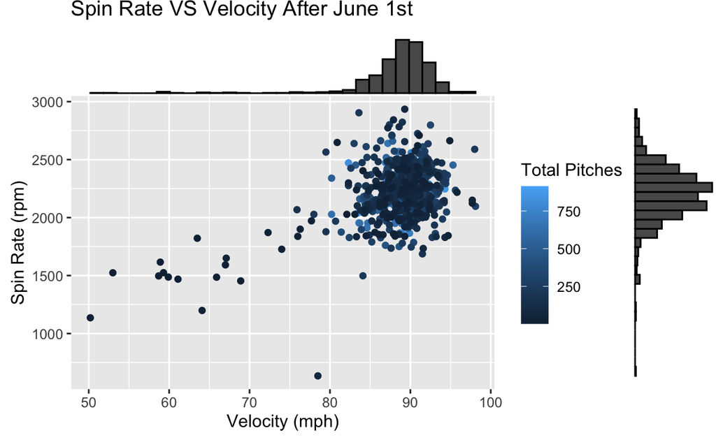

```r
aftgr <-
  aft %>%
  ggplot(aes(x = velocity, y = spin_rate, color = total_pitches)) +
  geom_point(stat = 'identity') +
  xlab('Velocity (mph)') +
  ylab('Spin Rate (rpm)') +
  ggtitle('Spin Rate VS Velocity After June 1st') +
  labs(color = 'Total Pitches')

p2 <-
  ggMarginal(aftgr, type = 'histogram')
p2
```

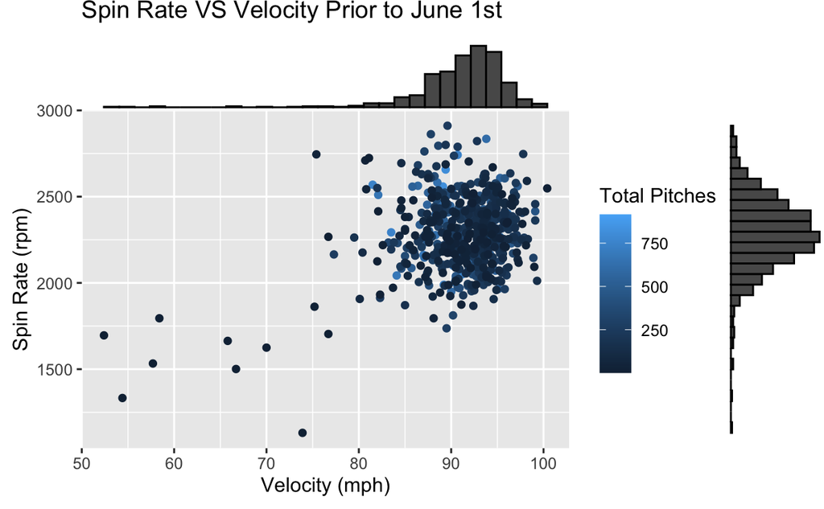

```r
p1
```

```r
b4abv <-
  b4%>%
  filter(total_pitches > 249)
b4abv
```

| pitches | player_id | player_name | total_pitches | pitch_percent | ba | iso | babip | slg | woba | xwoba | xba | hits | abs | launch_speed | launch_angle | spin_rate | velocity | effective_speed | whiffs | swings | takes | eff_min_vel | release_extension | pos3_int_start_distance | pos4_int_start_distance | pos5_int_start_distance | pos6_int_start_distance | pos7_int_start_distance | pos8_int_start_distance | … |
| --- | --- | --- | --- | --- | --- | --- | --- | --- | --- | --- | --- | --- | --- | --- | --- | --- | --- | --- | --- | --- | --- | --- | --- | --- | --- | --- | --- | --- | --- | --- |
| 915 | 621244 | Berríos, José | 915 | 100 | 0.223 | 0.158 | 0.294 | 0.381 | 0.292 | 0.340 | 0.261 | 48 | 215 | 86.4 | 10.5 | 2290 | 90.2 | 89.26 | 110 | 429 | 486 | -0.9 | 6.41 | 108 | 156 | 118 | 149 | 300 | 328 | … |
| 819 | 450203 | Morton, Charlie | 819 | 100 | 0.231 | 0.097 | 0.315 | 0.328 | 0.292 | 0.305 | 0.236 | 45 | 195 | 87.1 | 6.4 | 2559 | 89.1 | 88.86 | 109 | 379 | 440 | -0.2 | 6.28 | 109 | 151 | 121 | 150 | 300 | 321 | … |
| 807 | 628711 | Urías, Julio | 807 | 100 | 0.241 | 0.161 | 0.301 | 0.402 | 0.293 | 0.314 | 0.250 | 48 | 199 | 86.7 | 17.0 | 2657 | 89.4 | 88.32 | 110 | 415 | 392 | -1.1 | 5.53 | 112 | 156 | 116 | 150 | 299 | 317 | … |
| 779 | 554430 | Wheeler, Zack | 779 | 100 | 0.218 | 0.086 | 0.298 | 0.305 | 0.258 | 0.261 | 0.214 | 43 | 197 | 84.6 | 9.5 | 2373 | 95.3 | 96.66 | 102 | 396 | 383 | 1.4 | 7.17 | 112 | 152 | 116 | 150 | 297 | 323 | … |
| 776 | 605540 | Woodruff, Brandon | 776 | 100 | 0.126 | 0.038 | 0.186 | 0.164 | 0.177 | 0.249 | 0.189 | 23 | 183 | 86.2 | 5.1 | 2416 | 94.4 | 93.72 | 98 | 393 | 383 | -0.7 | 6.52 | 110 | 156 | 118 | 150 | 300 | 323 | … |
| 770 | 607192 | Glasnow, Tyler | 770 | 100 | 0.151 | 0.113 | 0.239 | 0.264 | 0.225 | 0.238 | 0.168 | 32 | 212 | 91.3 | 16.4 | 2556 | 94.1 | 95.40 | 137 | 394 | 376 | 1.3 | 7.37 | 107 | 159 | 119 | 150 | 302 | 321 | … |
| 751 | 605288 | Houser, Adrian | 751 | 100 | 0.230 | 0.137 | 0.267 | 0.366 | 0.300 | 0.317 | 0.242 | 37 | 161 | 89.3 | -0.2 | 2050 | 91.2 | 91.20 | 64 | 339 | 412 | 0.0 | 6.46 | 107 | 151 | 115 | 148 | 300 | 318 | … |
| 751 | 518876 | Kelly, Merrill | 751 | 100 | 0.274 | 0.177 | 0.326 | 0.452 | 0.338 | 0.344 | 0.270 | 51 | 186 | 90.6 | 11.5 | 2439 | 88.5 | 88.19 | 64 | 333 | 418 | -0.3 | 6.32 | 112 | 153 | 117 | 150 | 304 | 331 | … |
| 750 | 448179 | Hill, Rich | 750 | 100 | 0.199 | 0.125 | 0.254 | 0.324 | 0.270 | 0.320 | 0.242 | 35 | 176 | 90.1 | 14.1 | 2569 | 81.5 | 80.97 | 97 | 347 | 403 | -0.5 | 6.36 | 103 | 155 | 116 | 148 | 305 | 323 | … |
| 748 | 425844 | Greinke, Zack | 748 | 100 | 0.285 | 0.179 | 0.306 | 0.464 | 0.341 | 0.330 | 0.279 | 51 | 179 | 85.9 | 18.9 | 2293 | 83.5 | 82.77 | 58 | 326 | 422 | -0.7 | 5.96 | 114 | 155 | 116 | 151 | 289 | 324 | … |

[output cut: 190 more lines]

```r
aftabv <-
  aft%>%
  filter(total_pitches > 249)
aftabv
```

| pitches | player_id | player_name | total_pitches | pitch_percent | ba | iso | babip | slg | woba | xwoba | xba | hits | abs | launch_speed | launch_angle | spin_rate | velocity | effective_speed | whiffs | swings | takes | eff_min_vel | release_extension | pos3_int_start_distance | pos4_int_start_distance | pos5_int_start_distance | pos6_int_start_distance | pos7_int_start_distance | pos8_int_start_distance | … |
| --- | --- | --- | --- | --- | --- | --- | --- | --- | --- | --- | --- | --- | --- | --- | --- | --- | --- | --- | --- | --- | --- | --- | --- | --- | --- | --- | --- | --- | --- | --- |
| 914 | 622491 | Castillo, Luis | 914 | 100 | 0.178 | 0.056 | 0.237 | 0.234 | 0.240 | 0.291 | 0.225 | 35 | 197 | 86.9 | 3.5 | 2223 | 93.0 | 91.78 | 141 | 443 | 471 | -1.2 | 5.53 | 115 | 153 | 120 | 147 | 292 | 318 | … |
| 897 | 621111 | Buehler, Walker | 897 | 100 | 0.177 | 0.089 | 0.229 | 0.266 | 0.233 | 0.249 | 0.196 | 36 | 203 | 86.2 | 13.8 | 2536 | 91.3 | 91.54 | 112 | 436 | 461 | 0.2 | 6.35 | 111 | 157 | 119 | 153 | 300 | 319 | … |
| 885 | 592662 | Ray, Robbie | 885 | 100 | 0.196 | 0.132 | 0.283 | 0.328 | 0.253 | 0.249 | 0.191 | 40 | 204 | 89.7 | 17.3 | 2228 | 92.6 | 92.82 | 145 | 450 | 435 | 0.2 | 6.38 | 106 | 155 | 122 | 147 | 297 | 316 | … |
| 850 | 645261 | Alcantara, Sandy | 850 | 100 | 0.251 | 0.093 | 0.298 | 0.344 | 0.292 | 0.294 | 0.241 | 54 | 215 | 86.0 | 1.7 | 2247 | 94.3 | 93.68 | 92 | 454 | 396 | -0.6 | 5.97 | 107 | 151 | 115 | 149 | 300 | 318 | … |
| 838 | 656302 | Cease, Dylan | 838 | 100 | 0.243 | 0.189 | 0.319 | 0.432 | 0.327 | 0.322 | 0.241 | 45 | 185 | 86.9 | 14.6 | 2483 | 88.3 | 87.96 | 119 | 394 | 444 | -0.3 | 6.04 | 112 | 153 | 111 | 149 | 299 | 320 | … |
| 832 | 608337 | Giolito, Lucas | 832 | 100 | 0.242 | 0.204 | 0.295 | 0.446 | 0.312 | 0.282 | 0.231 | 45 | 186 | 87.1 | 21.5 | 1989 | 88.0 | 88.89 | 137 | 424 | 408 | 0.9 | 6.69 | 113 | 153 | 114 | 149 | 302 | 318 | … |
| 825 | 543294 | Hendricks, Kyle | 825 | 100 | 0.234 | 0.151 | 0.259 | 0.385 | 0.291 | 0.322 | 0.262 | 48 | 205 | 85.4 | 13.2 | 2038 | 83.4 | 79.28 | 74 | 405 | 420 | -4.1 | 5.75 | 112 | 159 | 113 | 151 | 296 | 323 | … |
| 813 | 425794 | Wainwright, Adam | 813 | 100 | 0.219 | 0.125 | 0.266 | 0.344 | 0.274 | 0.333 | 0.271 | 42 | 192 | 89.8 | 9.5 | 2472 | 82.3 | 81.62 | 64 | 354 | 459 | -0.7 | 6.49 | 116 | 155 | 116 | 149 | 299 | 317 | … |
| 804 | 641816 | Mahle, Tyler | 804 | 100 | 0.228 | 0.193 | 0.311 | 0.421 | 0.325 | 0.299 | 0.219 | 39 | 171 | 88.1 | 11.1 | 2273 | 90.8 | 91.40 | 132 | 376 | 428 | 0.6 | 6.55 | 114 | 154 | 118 | 147 | 294 | 318 | … |
| 801 | 641745 | Keller, Brad | 801 | 100 | 0.315 | 0.146 | 0.362 | 0.461 | 0.374 | 0.380 | 0.299 | 56 | 178 | 89.2 | 8.4 | 2372 | 90.4 | 90.09 | 71 | 351 | 450 | -0.3 | 5.83 | 107 | 158 | 117 | 145 | 299 | 325 | … |

[output cut: 261 more lines]

```r
babvgr <-
  b4abv %>%
  ggplot(aes(x = velocity, y = spin_rate, color = total_pitches)) +
  geom_point(stat = 'identity') +
  xlab('Velocity (mph)') +
  ylab('Spin Rate (rpm)') +
  labs(color = 'Total Pitches',
       title = 'Spin Rate vs Velocity Before June 1st',
       caption = 'For pitchers with over 250 pitches') +
  scale_color_viridis_c()
```

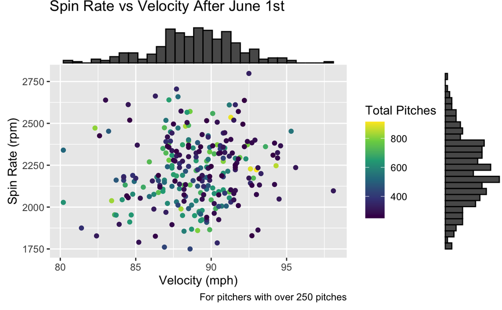

```r
afabvgr <-
  aftabv %>%
  ggplot(aes(x = velocity, y = spin_rate, color = total_pitches)) +
  geom_point(stat = 'identity') +
  xlab('Velocity (mph)') +
  ylab('Spin Rate (rpm)') +
  labs(color = 'Total Pitches',
       title = 'Spin Rate vs Velocity After June 1st',
       caption = 'For pitchers with over 250 pitches') +
  scale_color_viridis_c()

k1 <-
  ggMarginal(afabvgr, type = 'histogram')
k1
```

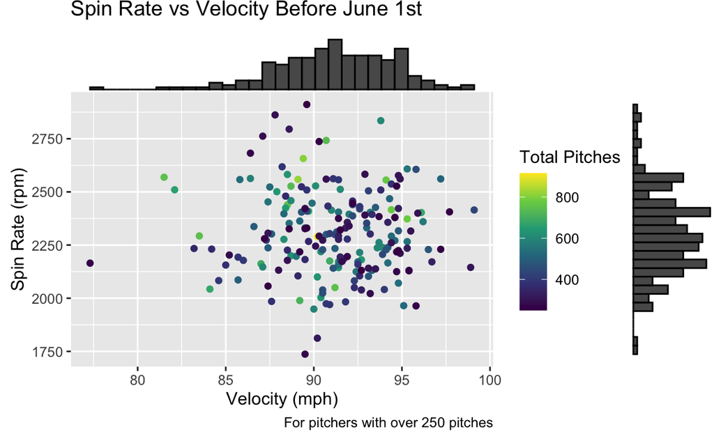

```r
g1 <-
  ggMarginal(babvgr, type = 'histogram')
g1
```

## Individual Pitcher Changes

#### Trevor Bauer

It’s hard to have any conversation about foreign substances in baseball without mentioning Trevor Bauer. From being someone who initially spoken against foreign substances, once even stating that they could be more powerful than steroids, to now being accused of having the most effective substance combination in the game, Bauer’s name has been brought up a lot.

```r
bauer <-
  read.csv('bauer advanced stats.csv')
bauer
```

| pitch_type | game_date | release_speed | release_pos_x | release_pos_z | player_name | batter | pitcher | events | description | spin_dir | spin_rate_deprecated | break_angle_deprecated | break_length_deprecated | zone | des | game_type | stand | p_throws | home_team | away_team | type | hit_location | bb_type | balls | strikes | game_year | pfx_x | pfx_z | plate_x | … |
| --- | --- | --- | --- | --- | --- | --- | --- | --- | --- | --- | --- | --- | --- | --- | --- | --- | --- | --- | --- | --- | --- | --- | --- | --- | --- | --- | --- | --- | --- | --- |
| SL | 2021-06-28 | 84.2 | -1.81 | 5.33 | Bauer, Trevor | 573131 | 545333 | strikeout | swinging_strike | NA | NA | NA | NA | 14 | Darin Ruf strikes out swinging. | R | R | R | LAD | SF | S | 2 |  | 1 | 2 | 2021 | 0.94 | -0.17 | 1.81 | … |
| SI | 2021-06-28 | 97.4 | -1.70 | 5.31 | Bauer, Trevor | 573131 | 545333 |  | foul | NA | NA | NA | NA | 14 | Darin Ruf strikes out swinging. | R | R | R | LAD | SF | S | NA |  | 1 | 2 | 2021 | -1.14 | 1.38 | 0.42 | … |
| SL | 2021-06-28 | 81.6 | -1.77 | 5.42 | Bauer, Trevor | 573131 | 545333 |  | called_strike | NA | NA | NA | NA | 3 | Darin Ruf strikes out swinging. | R | R | R | LAD | SF | S | NA |  | 1 | 1 | 2021 | 1.76 | -0.05 | 0.28 | … |
| SL | 2021-06-28 | 81.3 | -1.74 | 5.48 | Bauer, Trevor | 573131 | 545333 |  | called_strike | NA | NA | NA | NA | 5 | Darin Ruf strikes out swinging. | R | R | R | LAD | SF | S | NA |  | 1 | 0 | 2021 | 1.49 | -0.12 | 0.07 | … |
| SL | 2021-06-28 | 81.1 | -1.71 | 5.50 | Bauer, Trevor | 573131 | 545333 |  | ball | NA | NA | NA | NA | 11 | Darin Ruf strikes out swinging. | R | R | R | LAD | SF | B | NA |  | 0 | 0 | 2021 | 1.40 | 0.03 | -0.12 | … |
| SI | 2021-06-28 | 95.9 | -1.71 | 5.36 | Bauer, Trevor | 456781 | 545333 | field_out | hit_into_play | NA | NA | NA | NA | 4 | Donovan Solano grounds out, third baseman Justin Turner to first baseman Max Muncy. | R | R | R | LAD | SF | X | 5 | ground_ball | 3 | 2 | 2021 | -1.04 | 1.12 | -0.68 | … |
| SL | 2021-06-28 | 83.5 | -1.72 | 5.38 | Bauer, Trevor | 456781 | 545333 |  | foul | NA | NA | NA | NA | 9 | Donovan Solano grounds out, third baseman Justin Turner to first baseman Max Muncy. | R | R | R | LAD | SF | S | NA |  | 3 | 2 | 2021 | 1.39 | 0.02 | 0.75 | … |
| SL | 2021-06-28 | 81.6 | -1.72 | 5.35 | Bauer, Trevor | 456781 | 545333 |  | swinging_strike | NA | NA | NA | NA | 9 | Donovan Solano grounds out, third baseman Justin Turner to first baseman Max Muncy. | R | R | R | LAD | SF | S | NA |  | 3 | 1 | 2021 | 1.43 | 0.12 | 0.71 | … |
| SI | 2021-06-28 | 96.0 | -1.62 | 5.37 | Bauer, Trevor | 456781 | 545333 |  | ball | NA | NA | NA | NA | 14 | Donovan Solano grounds out, third baseman Justin Turner to first baseman Max Muncy. | R | R | R | LAD | SF | B | NA |  | 2 | 1 | 2021 | -1.21 | 1.25 | 0.27 | … |
| SL | 2021-06-28 | 82.4 | -1.67 | 5.49 | Bauer, Trevor | 456781 | 545333 |  | ball | NA | NA | NA | NA | 14 | Donovan Solano grounds out, third baseman Justin Turner to first baseman Max Muncy. | R | R | R | LAD | SF | B | NA |  | 1 | 1 | 2021 | 1.15 | -0.01 | 1.27 | … |

[output cut: 522 more lines]

```r
tbju28 <-
  bauer %>%
  filter(game_date == '2021-06-28')
tbju28
```

| pitch_type | game_date | release_speed | release_pos_x | release_pos_z | player_name | batter | pitcher | events | description | spin_dir | spin_rate_deprecated | break_angle_deprecated | break_length_deprecated | zone | des | game_type | stand | p_throws | home_team | away_team | type | hit_location | bb_type | balls | strikes | game_year | pfx_x | pfx_z | plate_x | … |
| --- | --- | --- | --- | --- | --- | --- | --- | --- | --- | --- | --- | --- | --- | --- | --- | --- | --- | --- | --- | --- | --- | --- | --- | --- | --- | --- | --- | --- | --- | --- |
| SL | 2021-06-28 | 84.2 | -1.81 | 5.33 | Bauer, Trevor | 573131 | 545333 | strikeout | swinging_strike | NA | NA | NA | NA | 14 | Darin Ruf strikes out swinging. | R | R | R | LAD | SF | S | 2 |  | 1 | 2 | 2021 | 0.94 | -0.17 | 1.81 | … |
| SI | 2021-06-28 | 97.4 | -1.70 | 5.31 | Bauer, Trevor | 573131 | 545333 |  | foul | NA | NA | NA | NA | 14 | Darin Ruf strikes out swinging. | R | R | R | LAD | SF | S | NA |  | 1 | 2 | 2021 | -1.14 | 1.38 | 0.42 | … |
| SL | 2021-06-28 | 81.6 | -1.77 | 5.42 | Bauer, Trevor | 573131 | 545333 |  | called_strike | NA | NA | NA | NA | 3 | Darin Ruf strikes out swinging. | R | R | R | LAD | SF | S | NA |  | 1 | 1 | 2021 | 1.76 | -0.05 | 0.28 | … |
| SL | 2021-06-28 | 81.3 | -1.74 | 5.48 | Bauer, Trevor | 573131 | 545333 |  | called_strike | NA | NA | NA | NA | 5 | Darin Ruf strikes out swinging. | R | R | R | LAD | SF | S | NA |  | 1 | 0 | 2021 | 1.49 | -0.12 | 0.07 | … |
| SL | 2021-06-28 | 81.1 | -1.71 | 5.50 | Bauer, Trevor | 573131 | 545333 |  | ball | NA | NA | NA | NA | 11 | Darin Ruf strikes out swinging. | R | R | R | LAD | SF | B | NA |  | 0 | 0 | 2021 | 1.40 | 0.03 | -0.12 | … |
| SI | 2021-06-28 | 95.9 | -1.71 | 5.36 | Bauer, Trevor | 456781 | 545333 | field_out | hit_into_play | NA | NA | NA | NA | 4 | Donovan Solano grounds out, third baseman Justin Turner to first baseman Max Muncy. | R | R | R | LAD | SF | X | 5 | ground_ball | 3 | 2 | 2021 | -1.04 | 1.12 | -0.68 | … |
| SL | 2021-06-28 | 83.5 | -1.72 | 5.38 | Bauer, Trevor | 456781 | 545333 |  | foul | NA | NA | NA | NA | 9 | Donovan Solano grounds out, third baseman Justin Turner to first baseman Max Muncy. | R | R | R | LAD | SF | S | NA |  | 3 | 2 | 2021 | 1.39 | 0.02 | 0.75 | … |
| SL | 2021-06-28 | 81.6 | -1.72 | 5.35 | Bauer, Trevor | 456781 | 545333 |  | swinging_strike | NA | NA | NA | NA | 9 | Donovan Solano grounds out, third baseman Justin Turner to first baseman Max Muncy. | R | R | R | LAD | SF | S | NA |  | 3 | 1 | 2021 | 1.43 | 0.12 | 0.71 | … |
| SI | 2021-06-28 | 96.0 | -1.62 | 5.37 | Bauer, Trevor | 456781 | 545333 |  | ball | NA | NA | NA | NA | 14 | Donovan Solano grounds out, third baseman Justin Turner to first baseman Max Muncy. | R | R | R | LAD | SF | B | NA |  | 2 | 1 | 2021 | -1.21 | 1.25 | 0.27 | … |
| SL | 2021-06-28 | 82.4 | -1.67 | 5.49 | Bauer, Trevor | 456781 | 545333 |  | ball | NA | NA | NA | NA | 14 | Donovan Solano grounds out, third baseman Justin Turner to first baseman Max Muncy. | R | R | R | LAD | SF | B | NA |  | 1 | 1 | 2021 | 1.15 | -0.01 | 1.27 | … |

[output cut: 88 more lines]

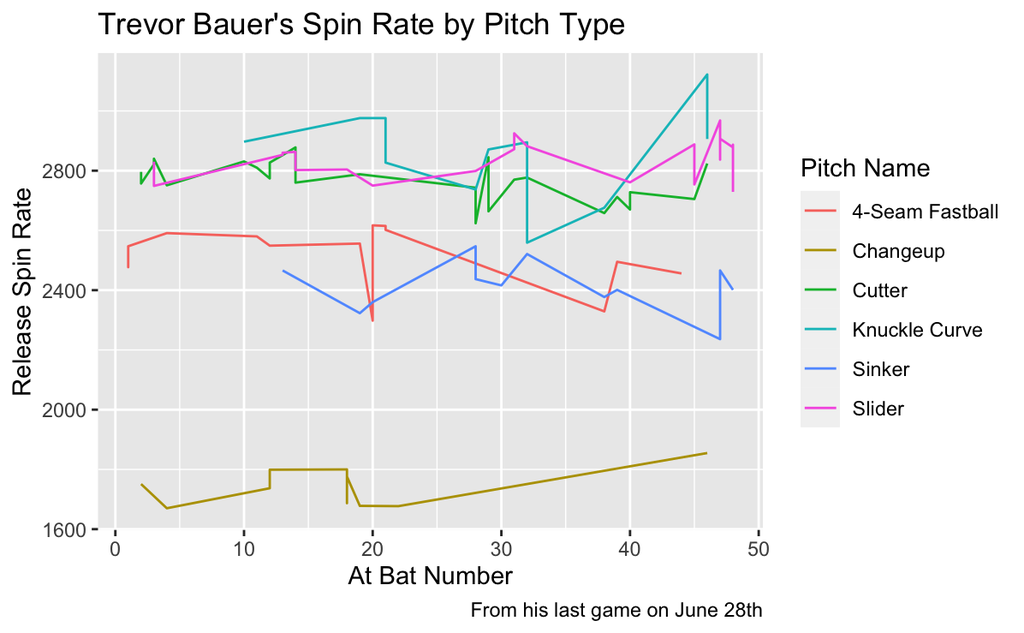

```r
tb28gr <-
  tbju28%>%
  ggplot(aes(x = at_bat_number , y = release_spin_rate, color = pitch_name)) +
  geom_line(stat = 'identity')+
  xlab('At Bat Number') +
  ylab('Release Spin Rate') +
  labs(title = "Trevor Bauer's Spin Rate by Pitch Type",
       color = 'Pitch Name',
       caption = 'From his last game on June 28th')
tb28gr
```

```r
tbju6 <-
  bauer %>%
  filter(game_date == '2021-06-06')
tbju6
```

| pitch_type | game_date | release_speed | release_pos_x | release_pos_z | player_name | batter | pitcher | events | description | spin_dir | spin_rate_deprecated | break_angle_deprecated | break_length_deprecated | zone | des | game_type | stand | p_throws | home_team | away_team | type | hit_location | bb_type | balls | strikes | game_year | pfx_x | pfx_z | plate_x | … |
| --- | --- | --- | --- | --- | --- | --- | --- | --- | --- | --- | --- | --- | --- | --- | --- | --- | --- | --- | --- | --- | --- | --- | --- | --- | --- | --- | --- | --- | --- | --- |
| SL | 2021-06-06 | 82.7 | -1.95 | 5.45 | Bauer, Trevor | 660670 | 545333 | strikeout | swinging_strike | NA | NA | NA | NA | 12 | Ronald Acuna strikes out swinging. | R | R | R | ATL | LAD | S | 2 |  | 0 | 2 | 2021 | 1.41 | -0.19 | 0.85 | … |
| SL | 2021-06-06 | 82.3 | -1.94 | 5.40 | Bauer, Trevor | 660670 | 545333 |  | foul | NA | NA | NA | NA | 5 | Ronald Acuna strikes out swinging. | R | R | R | ATL | LAD | S | NA |  | 0 | 1 | 2021 | 1.57 | -0.27 | 0.12 | … |
| SL | 2021-06-06 | 81.4 | -1.90 | 5.54 | Bauer, Trevor | 660670 | 545333 |  | called_strike | NA | NA | NA | NA | 2 | Ronald Acuna strikes out swinging. | R | R | R | ATL | LAD | S | NA |  | 0 | 0 | 2021 | 1.33 | -0.48 | 0.01 | … |
| FC | 2021-06-06 | 85.3 | -1.92 | 5.63 | Bauer, Trevor | 608331 | 545333 | sac_bunt | hit_into_play | NA | NA | NA | NA | 1 | Max Fried out on a sacrifice bunt, third baseman Justin Turner to first baseman Albert Pujols. Ehire Adrianza to 3rd. Ender Inciarte to 2nd. | R | L | R | ATL | LAD | X | 5 | ground_ball | 1 | 1 | 2021 | 0.29 | -0.15 | -0.30 | … |
| FF | 2021-06-06 | 95.2 | -1.79 | 5.62 | Bauer, Trevor | 608331 | 545333 |  | foul_bunt | NA | NA | NA | NA | 8 | Max Fried out on a sacrifice bunt, third baseman Justin Turner to first baseman Albert Pujols. Ehire Adrianza to 3rd. Ender Inciarte to 2nd. | R | L | R | ATL | LAD | S | NA |  | 1 | 0 | 2021 | -0.85 | 1.43 | -0.22 | … |
| FC | 2021-06-06 | 86.1 | -2.12 | 5.70 | Bauer, Trevor | 608331 | 545333 |  | ball | NA | NA | NA | NA | 11 | Max Fried out on a sacrifice bunt, third baseman Justin Turner to first baseman Albert Pujols. Ehire Adrianza to 3rd. Ender Inciarte to 2nd. | R | L | R | ATL | LAD | B | NA |  | 0 | 0 | 2021 | 0.52 | -0.21 | -0.97 | … |
| KC | 2021-06-06 | 80.9 | -1.61 | 5.92 | Bauer, Trevor | 542255 | 545333 | single | hit_into_play | NA | NA | NA | NA | 2 | Ender Inciarte singles on a line drive to center fielder Cody Bellinger. Abraham Almonte scores. Ehire Adrianza to 2nd. | R | L | R | ATL | LAD | X | 8 | line_drive | 0 | 2 | 2021 | 0.82 | -1.53 | 0.04 | … |
| SL | 2021-06-06 | 80.8 | -2.03 | 5.46 | Bauer, Trevor | 542255 | 545333 |  | swinging_strike | NA | NA | NA | NA | 9 | Ender Inciarte singles on a line drive to center fielder Cody Bellinger. Abraham Almonte scores. Ehire Adrianza to 2nd. | R | L | R | ATL | LAD | S | NA |  | 0 | 1 | 2021 | 1.47 | -0.40 | 0.60 | … |
| SI | 2021-06-06 | 93.9 | -1.74 | 5.67 | Bauer, Trevor | 542255 | 545333 |  | called_strike | NA | NA | NA | NA | 9 | Ender Inciarte singles on a line drive to center fielder Cody Bellinger. Abraham Almonte scores. Ehire Adrianza to 2nd. | R | L | R | ATL | LAD | S | NA |  | 0 | 0 | 2021 | -1.01 | 1.63 | 0.38 | … |
| FC | 2021-06-06 | 85.5 | -1.87 | 5.62 | Bauer, Trevor | 661388 | 545333 | field_out | hit_into_play | NA | NA | NA | NA | 5 | William Contreras bunt pops out softly to catcher Will Smith in foul territory. | R | R | R | ATL | LAD | X | 2 | popup | 1 | 0 | 2021 | 0.25 | 0.25 | 0.04 | … |

[output cut: 90 more lines]

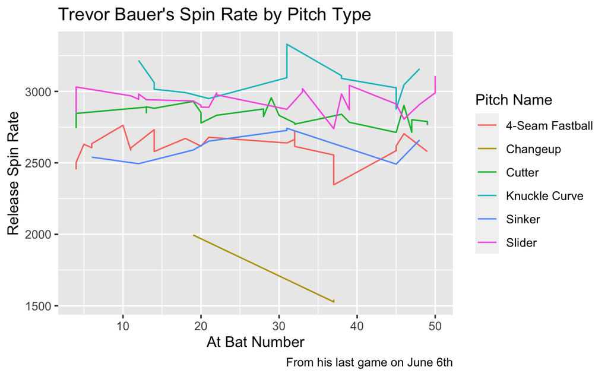

```r
tb6gr <-
  tbju6%>%
  ggplot(aes(x = at_bat_number , y = release_spin_rate, color = pitch_name)) +
  geom_line(stat = 'identity')+
  xlab('At Bat Number') +
  ylab('Release Spin Rate') +
  labs(title = "Trevor Bauer's Spin Rate by Pitch Type",
       color = 'Pitch Name',
       caption = 'From his last game on June 6th')
tb6gr
```

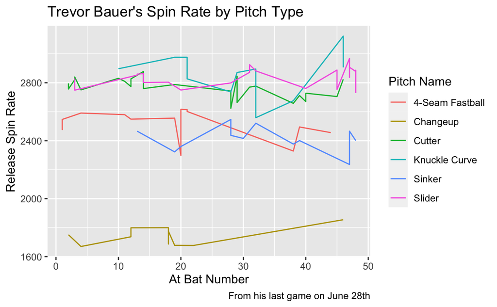

```r
tb28gr
```